```r
library(tidyr)
library(ggplot2)
library(hflights)
library(devtools)
# devtools::install_github("hadley/lazyeval")
# devtools::install_github("hadley/dplyr")
# might have
library(dplyr)
```

### Create working data frame

```r
df <- tbl_df(hflights)
```

Quick data visualization commands you should know

1. **head()**
2. **View()**
3. **str()**
4. **summary()**
5. **df[1:5,]**
6. **df[1:5,“Month”]**
7. **df[1:5, c(“Month”, “FlightNum”)]**

## tidyr

Changing format of data frames

**Example data** [R-bloggers](http://www.r-bloggers.com/introducing-tidyr/)

```r
set.seed(10)
messy <- data.frame(
  id = 1:4,
  trt = sample(rep(c('control', 'treatment'), each = 2)),
  work.T1 = runif(4),
  home.T1 = runif(4),
  work.T2 = runif(4),
  home.T2 = runif(4)
)
```

### gather()

From wide to long formatted data

```r
tidier <- gather(messy, key, value, -id, -trt)
```

### separate()

Split a regular expression column into new columns based on a common delimiter

```r
tidy <- separate(tidier, key, into=c("location","time"), sep = "\\.")
```

### spread()

Back to wide formated data (not used as often because long-formatted data is more widely used)

```r
spreadDF <- spread(tidier, key,value)
```

[Hadley’s in-depth data structure rant](https://github.com/hadley/tidyr/blob/master/vignettes/tidy-data.Rmd)

## dplyr

### filter() & slice()

Subset rows of a data frame. The first argument is the name of the data frame, and the second and subsequent are filtering expressions evaluated in the context of that data frame

```r
Jan1 <- filter(df, Month == 1, DayofMonth == 1)

JFMA <- filter(df, Month <= 4)

JFMA <- filter(df, Month != 4)

JFMA <- filter(df, !is.na(Month))

JAA <- filter(df, Month == 1 & UniqueCarrier == "AA")

SLdf <- slice(df, 1:200)

SLdf <- slice(df, n())
```

### arrange()

Reorder data frame. It takes a data frame, and a set of column names to order by.

```r
orderedDF <- arrange(df, DayofMonth,Month,Year)
```

**NOTE** default ordering for `arrange` is ascending

Use `desc()` to reverse default order

```r
DescorderedDF <- arrange(df, desc(DayofMonth),desc(Month),desc(Year))
```

### select() and rename()

Select columns from a given data frame. Takes a data frame and a set of columns to keep (or eliminate)

```r
selectDF <- dplyr::select(df, Month, DayofMonth,UniqueCarrier, AirTime, ArrDelay)

selectDF1 <- dplyr::select(df, month = Month)
```

We can also selectively get rid of columns

```r
selectDF1 <- dplyr::select(df, -Month, -DayofMonth, -UniqueCarrier, -AirTime, -ArrDelay)
```

We can also select a range of columns

```r
selectDF2 <- dplyr::select(df, Year:DepDelay)
```

Similarly, we can eliminate columns from `Year:DepDelay` by `-(Year:DepDelay)`

```r
selectDF3 <- dplyr::select(df, -(Year:DepDelay))
```

We can also keep or eliminate columns that contain common strings

```r
selectDF4 <- dplyr::select(df, contains("Month"))
```

### mutate()

This is used to add new columns to an exisiting data frame

```r
mutDF <- mutate(df, gain = ArrDelay - DepDelay, speed = Distance / AirTime * 60)
```

We can include conditionals while creating new columns!

```r
mutConDF <- mutate(df, MonthName = ifelse(Month == 1, "Jan",
                                          ifelse(Month == 2, "Feb",
                                                 ifelse(Month == 3, "Mar", "etc"))))

mutConDF1 <- mutate(df, tripLength = ifelse(Distance >=3000, "Long",
                                            ifelse(Distance >= 2000, "Medium",
                                                   ifelse(Distance >= 100, "Short", "Consider Driving"))))
```

### group_by() & distinct()

Group data frame by unique occurences present in user input columns

**Note** this becomes more useful later

```r
grpDF <- group_by(df, Month)
```

Pull out unique occurences from a dataframe

```r
dDF <- distinct(df, Month, UniqueCarrier)
```

### summarise()

Generate summary statistics for data

```r
sumDF <- summarise(df, delays = mean(DepDelay))
sumDF
```

```
## Source: local data frame [1 x 1]
##
##   delays
## 1     NA
```

```r
sumDF <- summarise(df, delays = mean(DepDelay,na.rm=TRUE))
sumDF
```

```
## Source: local data frame [1 x 1]
##
##   delays
## 1  9.445
```

```r
grpSumDF <- summarise(grpDF, delays = mean(DepDelay,na.rm=TRUE))
```

**Notice** summary statistics are different for grouped data. Mean is generated for each of the grouping variables!

# Exercise

## Solution

```r
df <- hflights
df1 <- filter(df, Distance < 1000, !is.na(DepTime))
df2 <- mutate(df1, spDay = ifelse(DepTime > 1800, "night",
                                ifelse(DepTime > 1200, "afternoon",
                                       ifelse(DepTime > 600, "late morning", "early morning"))))
df3 <- dplyr::select(df2, Month, Origin, spDay, UniqueCarrier, DepDelay, Distance)
df4 <- group_by(df3, Month, Origin, spDay, UniqueCarrier)
sumDF <- summarise(df4, avgDelay = mean(DepDelay, na.rm = TRUE),
                   avgDist = mean(Distance, na.rm = TRUE))
sumDF1 <- arrange(sumDF, spDay, UniqueCarrier)
```

**Cluttered workspace**

## %>%

Use the above chaining operator to join different commands together. Save computation time and don’t clutter your workspace!

#### Solution B

```r
df <- hflights

df1 <- df %>%
  filter(Distance < 1000, !is.na(DepTime))%>%
  mutate(spDay = ifelse(DepTime > 1800, "night",
                                ifelse(DepTime > 1200, "afternoon",
                                       ifelse(DepTime > 600, "late morning", "early morning"))))%>%
  dplyr::select(Month, Origin, spDay, UniqueCarrier, DepDelay, Distance)%>%
  group_by(Month, Origin, spDay, UniqueCarrier)%>%
  summarise(avgDelay = mean(DepDelay, na.rm = TRUE),
            avgDist = mean(Distance, na.rm = TRUE))%>%
  arrange(spDay, UniqueCarrier)

identical(df1, sumDF1)
```

```
## [1] TRUE
```

### join()

Merge two data frames by common variables

```r
df2 <- df1%>%
  select(-spDay)%>%
  left_join(df,., by = c("Month", "Origin", "UniqueCarrier"))
```

# Visualize data ggplot()

### geom_boxplot()

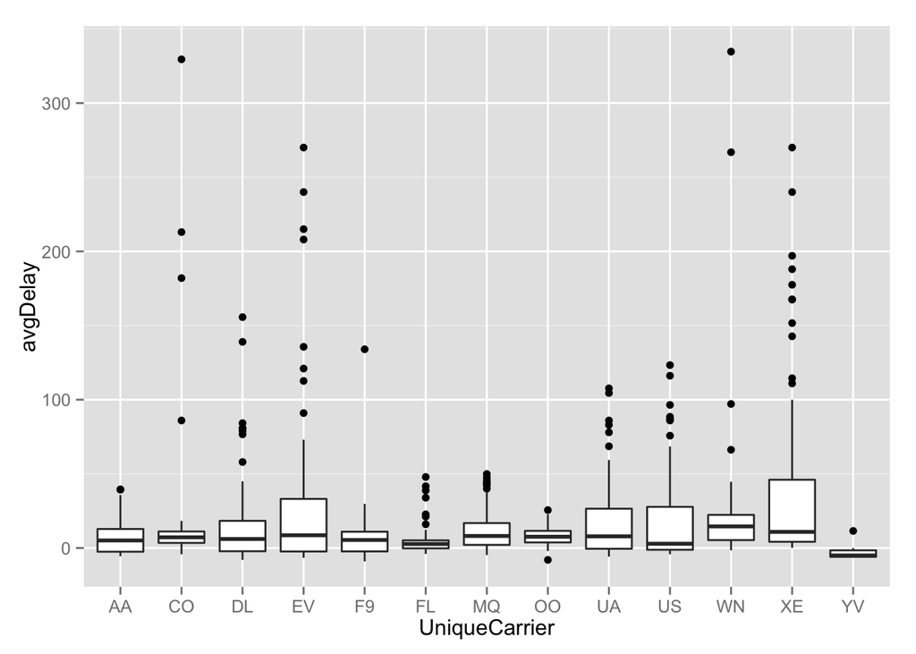

```r
ggplot(df1)+
  aes(x=UniqueCarrier, y = avgDelay)+
  geom_boxplot()
```

### facet_grid()

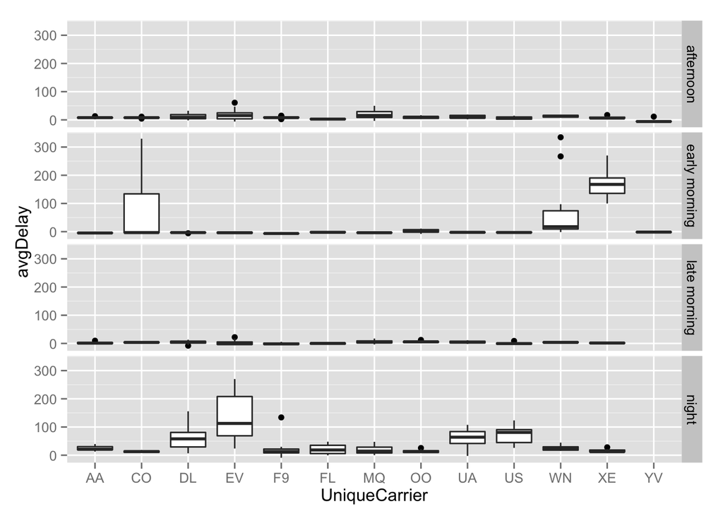

```r
ggplot(df1)+
  aes(x=UniqueCarrier, y = avgDelay)+
  geom_boxplot()+
  facet_grid(spDay~.)
```

Fix scales

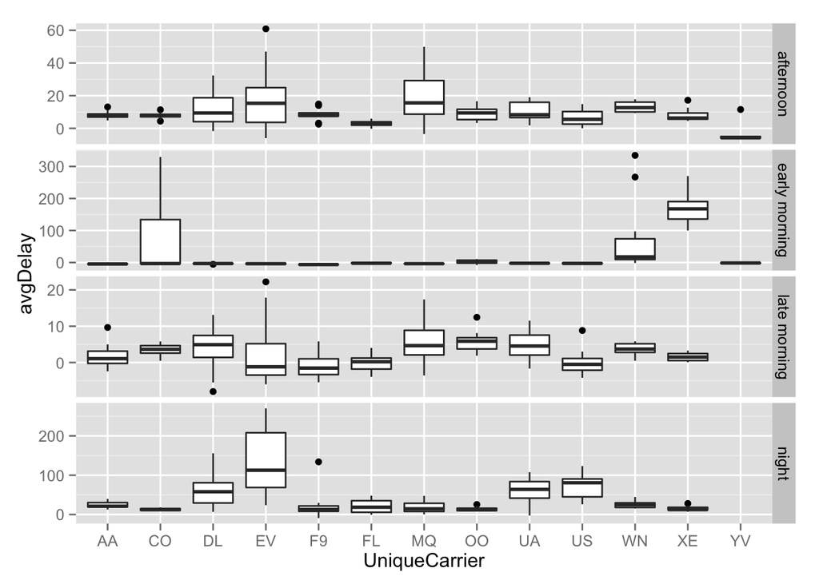

```r
ggplot(df1)+
  aes(x=UniqueCarrier, y = avgDelay)+
  geom_boxplot()+
  facet_grid(spDay~., scales = "free_y")
```

### geom_jitter()

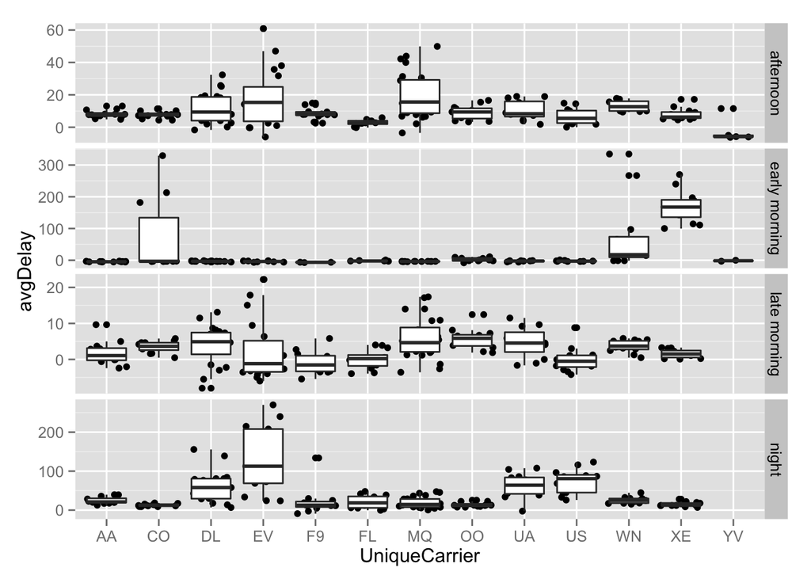

```r
ggplot(df1)+
  aes(x=UniqueCarrier, y = avgDelay)+
  geom_jitter()+
  geom_boxplot()+
  facet_grid(spDay~., scales = "free_y")
```

### Customization

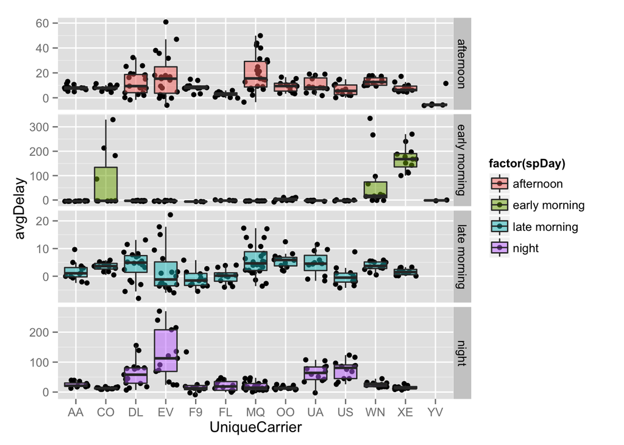

```r
ggplot(df1)+
  aes(x=UniqueCarrier, y = avgDelay, fill = factor(spDay))+
  geom_jitter()+
  geom_boxplot(alpha=.5,outlier.colour = NA)+
  facet_grid(spDay~., scales = "free_y")
```

### geom_histogram() and geom_density()

```
## stat_bin: binwidth defaulted to range/30. Use 'binwidth = x' to adjust this.
```

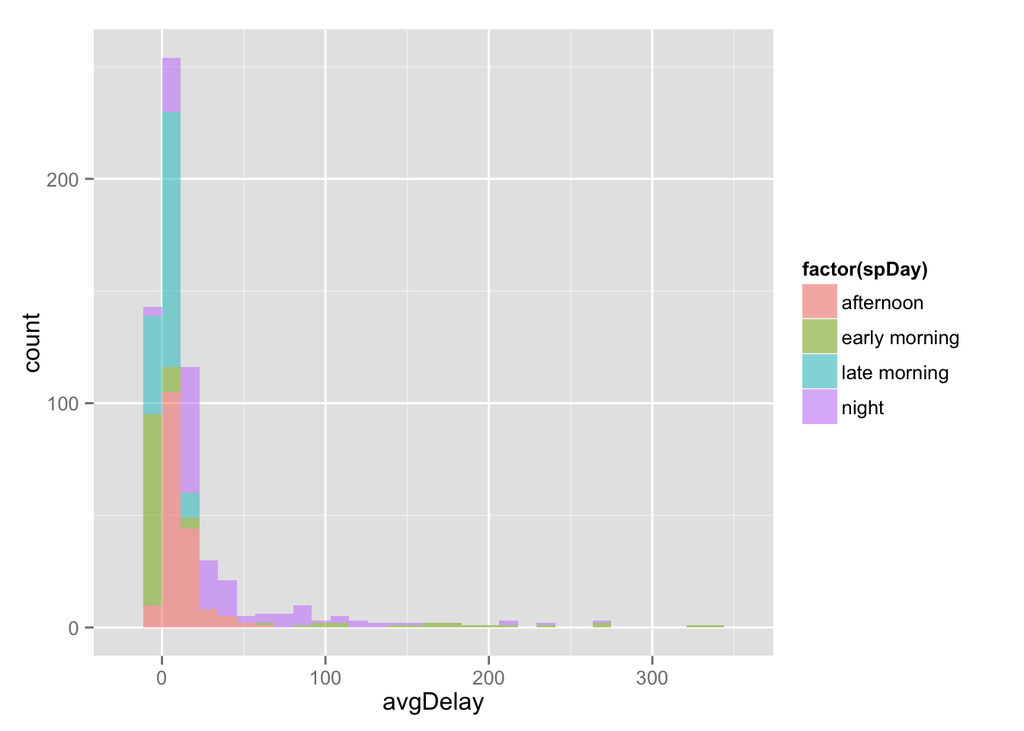

```r
ggplot(df1)+
  aes(x = avgDelay, fill = factor(spDay))+
  geom_histogram(alpha=.5)
```

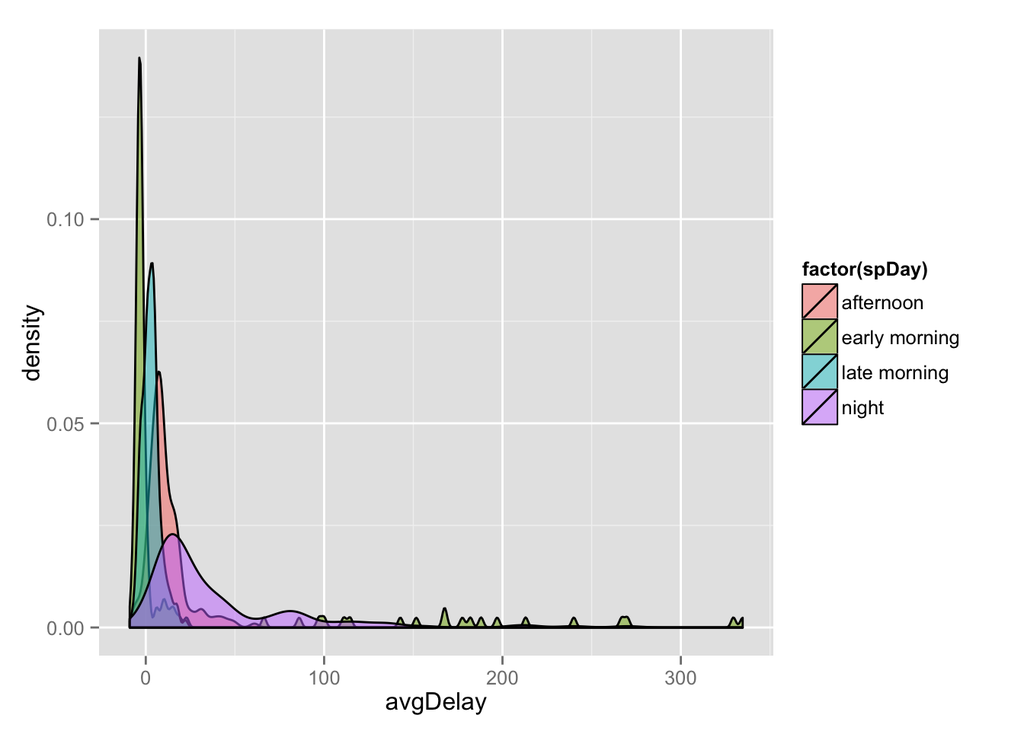

```r
ggplot(df1)+
  aes(x = avgDelay, fill = factor(spDay))+
  geom_density(alpha=.5)
```

### geom_point()

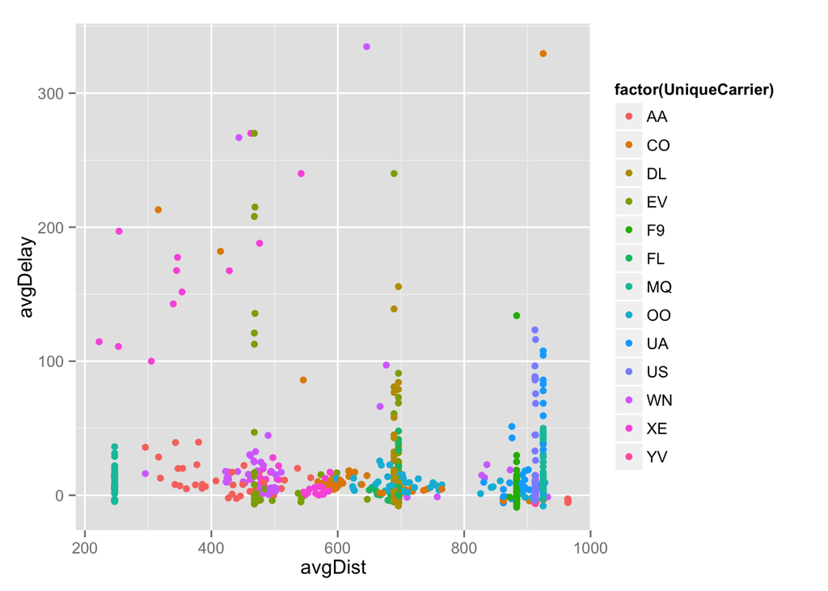

```r
ggplot(df1)+
  aes(y=avgDelay, x = avgDist, color = factor(UniqueCarrier))+
  geom_point()
```

### Make it ¡¡¡POP!!!

You can control **ALL** aspects of your plot. Here is the Andersen lab presentation standard

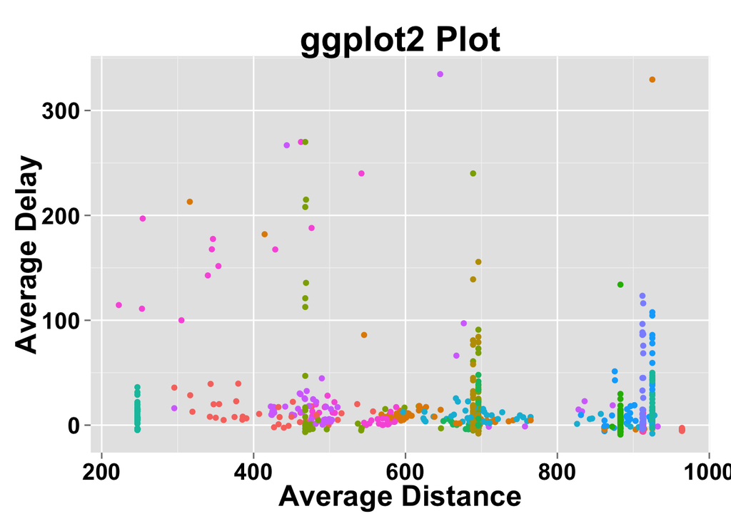

```r
presentation <- theme(axis.text.x = element_text(size=16, face="bold", color="black"),
                      axis.text.y = element_text(size=16, face="bold", color="black"),
                      axis.title.x = element_text(size=20, face="bold", color="black"),
                      axis.title.y = element_text(size=20, face="bold", color="black"),
                      strip.text.x = element_text(size=20, face="bold", color="black"),
                      strip.text.y = element_text(size=20, face="bold", color="black"),
                      plot.title = element_text(size=24, face="bold"),
                      legend.position = "none")

ggplot(df1)+
  aes(y=avgDelay, x = avgDist, color = factor(UniqueCarrier))+
  geom_point()+ presentation +
  labs(x = "Average Distance", y = "Average Delay", title = "ggplot2 Plot")
```

[Explore ggplot2 geoms](http://docs.ggplot2.org/0.9.3.1/index.html) [Explore ggplot2 themes](http://docs.ggplot2.org/dev/vignettes/themes.html)

# Put it all together

### Data -> tidyr -> dplyr -> ggplot

```r
cars <- tbl_df(mtcars)
head(cars)
```

```
## Source: local data frame [6 x 11]
##
##    mpg cyl disp  hp drat    wt  qsec vs am gear carb
## 1 21.0   6  160 110 3.90 2.620 16.46  0  1    4    4
## 2 21.0   6  160 110 3.90 2.875 17.02  0  1    4    4
## 3 22.8   4  108  93 3.85 2.320 18.61  1  1    4    1
## 4 21.4   6  258 110 3.08 3.215 19.44  1  0    3    1
## 5 18.7   8  360 175 3.15 3.440 17.02  0  0    3    2
## 6 18.1   6  225 105 2.76 3.460 20.22  1  0    3    1
```

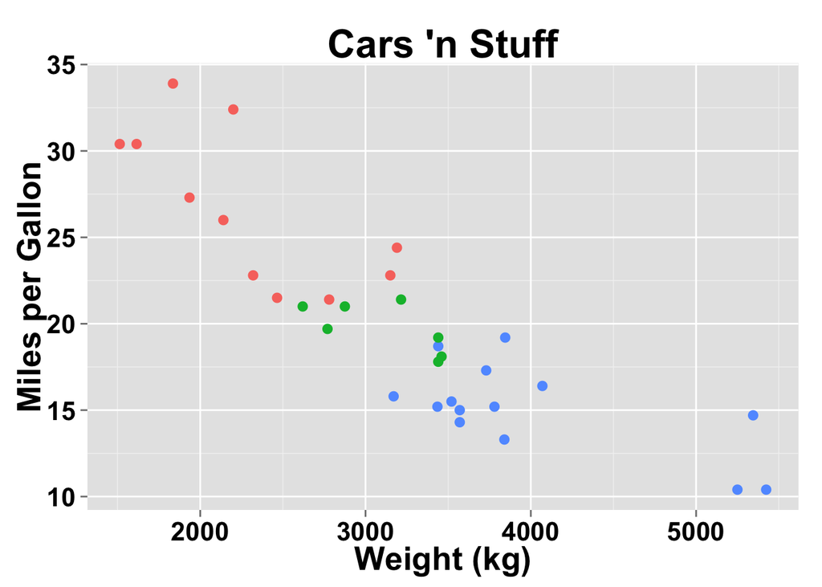

```r
cars %>%
  mutate(model = row.names(cars)) %>%
  select(mpg, wt, hp, cyl, model) %>%
  mutate(wtTra = wt*1000)%>%
  select(-wt)%>%
#   gather(feature, value, -model) %>%
  ggplot(.)+
  aes(x = wtTra, y = mpg, color = factor(cyl))+
  geom_point(size = 3)+
  presentation+
  labs(x = "Weight (kg)", y = "Miles per Gallon", title = "Cars 'n Stuff")
```

```r
flowers <- tbl_df(iris)
flowers
```

```
## Source: local data frame [150 x 5]
##
##    Sepal.Length Sepal.Width Petal.Length Petal.Width Species
## 1           5.1         3.5          1.4         0.2  setosa
## 2           4.9         3.0          1.4         0.2  setosa
## 3           4.7         3.2          1.3         0.2  setosa
## 4           4.6         3.1          1.5         0.2  setosa
## 5           5.0         3.6          1.4         0.2  setosa
## 6           5.4         3.9          1.7         0.4  setosa
## 7           4.6         3.4          1.4         0.3  setosa
## 8           5.0         3.4          1.5         0.2  setosa
## 9           4.4         2.9          1.4         0.2  setosa
## 10          4.9         3.1          1.5         0.1  setosa
## ..          ...         ...          ...         ...     ...
```

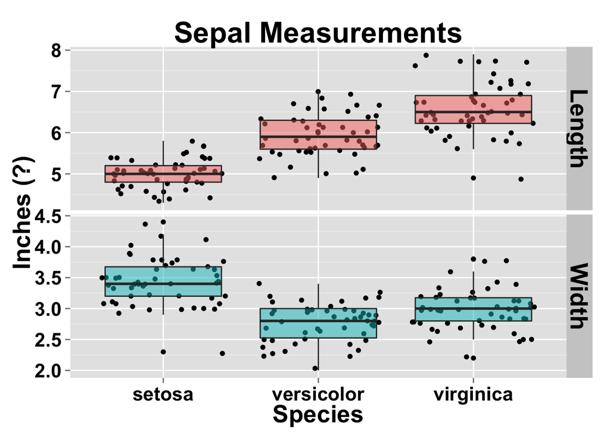

```r
flowers %>%
  gather(feature, value, -Species)%>%
  separate(feature, into = c("Part","Measurement"))%>%
  filter(Part == "Sepal")%>%
  ggplot(.)+
  aes(x = Species, y = value, fill = factor(Measurement))+
  geom_jitter()+
  geom_boxplot(alpha = .5, outlier.color = NA)+
  facet_grid(Measurement~., scales = "free")+
  presentation+
  labs(title = "Sepal Measurements", y = "Inches (?)")
```

# Beers for Hadley

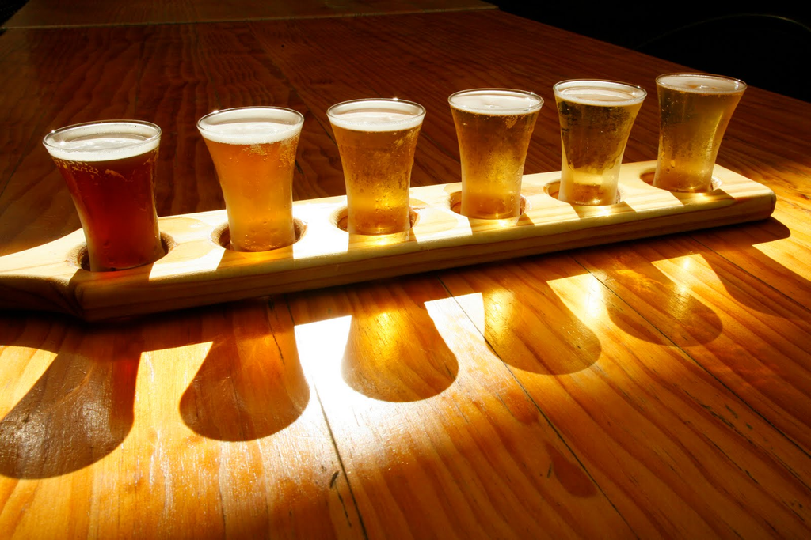